# Big Mac

This dataset has been uploaded on Kaggle website.

```r
#dollars_ex is the conversation rate with the local currency.

#import data
library(dplyr)

bigmac <- read.csv("BigmacPrice.csv", header = TRUE)

#rename columns
names(bigmac)[names(bigmac) == "name"] <- "country"

print(bigmac)
```

```
##            date currency_code              country  local_price dollar_ex
## 1    2000-04-01           ARS            Argentina 2.500000e+00         1
## 2    2000-04-01           AUD            Australia 2.590000e+00         1
## 3    2000-04-01           BRL               Brazil 2.950000e+00         1
## 4    2000-04-01           GBP              Britain 1.900000e+00         1
## 5    2000-04-01           CAD               Canada 2.850000e+00         1
## 6    2000-04-01           CLP                Chile 1.260000e+03       514
## 7    2000-04-01           CNY                China 9.900000e+00         8
## 8    2000-04-01           CZK       Czech Republic 5.437000e+01        39
## 9    2000-04-01           DKK              Denmark 2.475000e+01         8
## 10   2000-04-01           EUR            Euro area 2.560000e+00         1
## 11   2000-04-01           HKD            Hong Kong 1.020000e+01         7
## 12   2000-04-01           HUF              Hungary 3.390000e+02       279
## 13   2000-04-01           IDR            Indonesia 1.450000e+04      7945
## 14   2000-04-01           ILS               Israel 1.450000e+01         4
```

[output cut: 3879 more lines]

```r
#convert date to date format

bigmac$date <-as.Date(bigmac$date, format = "%Y-%m-%d")

#average price per country
library(dplyr)

bigmac_grouped <- bigmac %>%
  group_by(country)

bigmac_avg <- bigmac_grouped %>%
  summarise(avg_price = mean(dollar_price))

print(bigmac_avg)
```

```
## # A tibble: 74 × 2
##    country    avg_price
##    <chr>          <dbl>
##  1 Argentina       3.29
##  2 Australia       4.82
##  3 Austria         3.55
##  4 Azerbaijan      4.09
##  5 Bahrain         1.41
##  6 Belgium         4.04
##  7 Brazil          5.33
##  8 Britain         2.67
##  9 Canada          5.12
## 10 Chile           3.39
## # ℹ 64 more rows
```

[figure not shown]

```r
#graph avg
library(ggplot2)

graph_bigmac_avg <- ggplot(bigmac_avg, aes(x=country, y=avg_price)) +
  geom_segment( aes(x=country, xend=country, y=0, yend=avg_price
), color="skyblue") +
  geom_point( color="blue", size=4, alpha=0.6) +
  labs(
  title = "Average price of a bigmac per country since 2000",
  y = "Average price in dollars", x = "Countries"
)+
  theme_light() +
  coord_flip() +
  theme(
    panel.grid.major.y = element_blank(),
    panel.border = element_blank(),
    axis.ticks.y = element_blank()
)

graph_bigmac_avg
```

On the blue graph, we see that Norway has the most expensive bigmac in average, and Oman and Kowait the most cheepest ones.

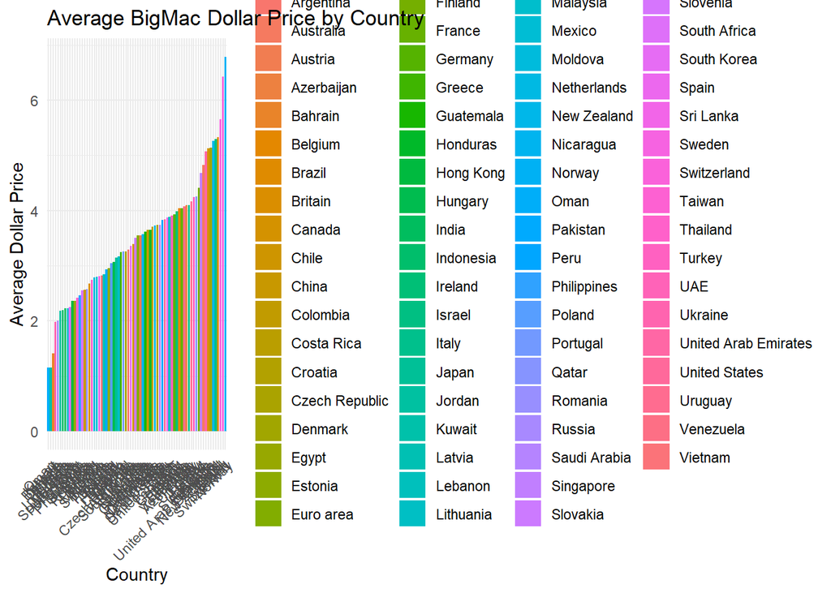

```r
# Average Dollar price bar plot
bigmac %>%
  group_by(country) %>%
  summarize(mean_dollar_price = mean(dollar_price)) %>%
  ggplot(aes(x = reorder(country, mean_dollar_price), y = mean_dollar_price, fill = country)) +
  geom_bar(stat = "identity") +
  theme_minimal() +
  theme(axis.text.x = element_text(angle = 45, hjust = 1)) +
  labs(title = "Average BigMac Dollar Price by Country", x = "Country", y = "Average Dollar Price")
```

On the previous graph, we can see the cheapest to the most expensive bigmac sandwich in dollars.

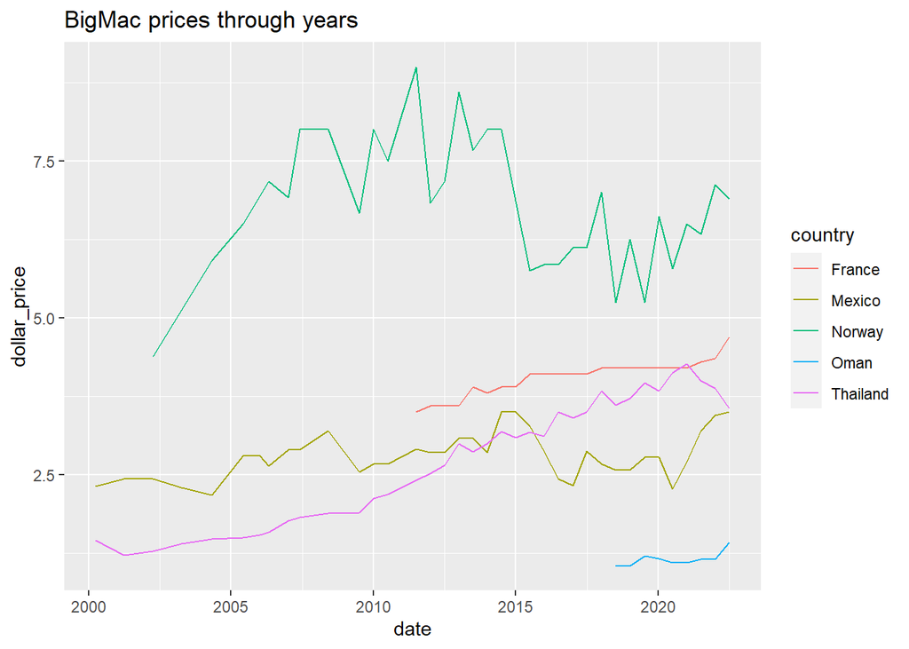

```r
#filter countries
library(ggplot2)
library(dplyr)

bigmac_subset <- bigmac %>%
  filter(country %in% c("Norway", "Oman", "Thailand", "Mexico", "France"))

bigmac_subset$date <- as.Date(paste0(bigmac_subset$date, "-01-01"))

ggplot(data = bigmac_subset, aes(x = date, y = dollar_price, color = country)) +
  geom_line() +
  labs(title = "BigMac prices through years",
       x = "date",
       y = "dollar_price") +
  scale_color_discrete(name = "country")
```

```r
#Compute the number of data per country
library(dplyr)

data_country <- bigmac %>%
  group_by(country) %>%
  summarise(num_data = n())

print(data_country)
```

```
## # A tibble: 74 × 2
##    country    num_data
##    <chr>         <int>
##  1 Argentina        37
##  2 Australia        37
##  3 Austria          23
##  4 Azerbaijan        9
##  5 Bahrain           9
##  6 Belgium          23
##  7 Brazil           37
##  8 Britain          37
##  9 Canada           37
## 10 Chile            37
## # ℹ 64 more rows
```

We see that Oman has only 9 data and Germany only 23. It is a few compared to Norway that has 33 data and Mexico 37.

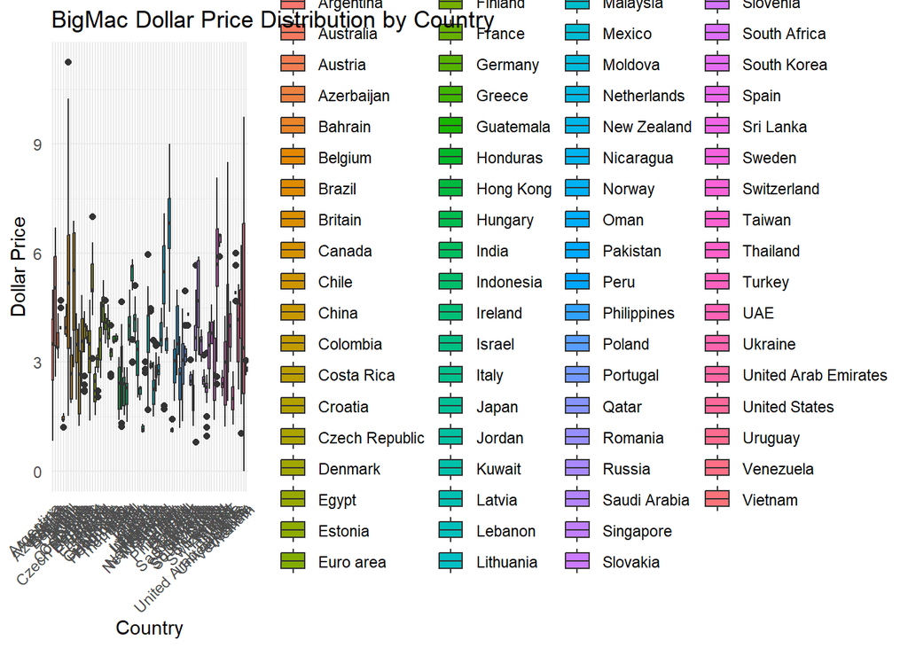

```r
# Boxplot to see the prices scale per country
ggplot(data = bigmac, aes(x = country, y = dollar_price, fill = country)) +
  geom_boxplot() +
  theme_minimal() +
  theme(axis.text.x = element_text(angle = 45, hjust = 1)) +
  labs(title = "BigMac Dollar Price Distribution by Country", x = "Country", y = "Dollar Price")
```

On this graph, we can see the scale of the different prices of a Bigmac sandwich per country. We can see that in Venezuela, in Brazil, in Turkey and in Australia, the prices fluctuate a lot. At the opposite, some countries as Taiyan, Switzerland and Honduras have almost the same price for years. We can probably explain this variation with the economical and political situation of the given country.

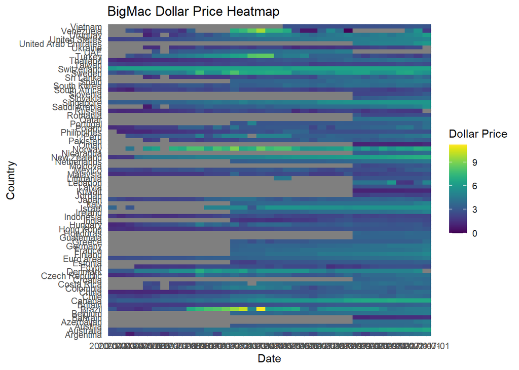

```r
library(tidyr)
library(viridis)

# Heatmap to see the evolution of dollars price per country
bigmac %>%
  group_by(country, date) %>%
  summarize(mean_dollar_price = mean(dollar_price)) %>%
  spread(date, mean_dollar_price) %>%
  gather(date, mean_dollar_price, -country) %>%
  ggplot(aes(x = date, y = country, fill = mean_dollar_price)) +
  geom_tile() +
  scale_fill_viridis(name = "Dollar Price") +
  theme_minimal() +
  labs(title = "BigMac Dollar Price Heatmap", x = "Date", y = "Country")
```

This heatmap displays the the level of price per country. The lighter color shows the highest prices, and at the opposite, the darker colors represent the lowest prices. The prices change through years. Indeed, we can see that in Brazil, the prices were quite cheap until 2007. Then they started to increase until 2013. And from 2013, the prices decrease again. For a lot of countries we can see that in 2010-2013, the prices increased.

Ici j’ai rajouté les régions géographiques pour chaques pays pour voir si les groupes sont cohérants

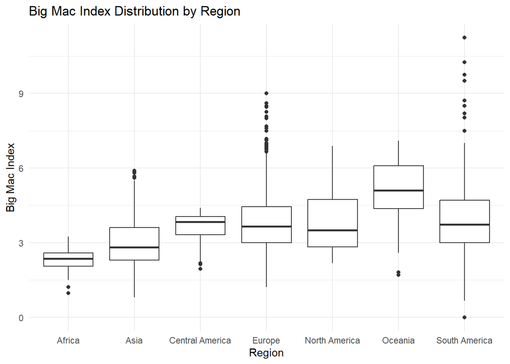

```r
#Adding Region to the dataset
country_region <- c("South America", "Oceania", "South America", "Europe", "North America", "South America", "Asia", "Europe", "Europe", "Europe", "Asia", "Europe", "Asia", "Asia", "Asia", "Asia", "North America", "Oceania", "Europe", "Europe", "Asia", "Africa", "Asia", "Europe", "Europe", "Asia", "Asia", "North America", "Asia", "Europe", "South America", "Europe", "South America", "Africa", "South America", "Central America", "Asia", "Asia", "Asia", "Europe", "South America", "Asia", "Europe", "Europe", "Europe", "Europe", "Europe", "Europe", "Europe", "Asia", "Europe", "Europe", "Europe", "Europe", "Europe", "Europe", "Asia", "Asia", "Asia", "Asia", "Europe", "Central America", "Central America", "Asia", "Asia", "Europe", "Asia", "Europe", "Asia", "Central America", "Asia", "Asia", "Europe", "Europe", "Europe", "Asia")
names(country_region) <- c("Argentina", "Australia", "Brazil", "Britain", "Canada", "Chile", "China", "Czech Republic", "Denmark", "Euro area", "Hong Kong", "Hungary", "Indonesia", "Israel", "Japan", "Malaysia", "Mexico", "New Zealand", "Poland", "Russia", "Singapore", "South Africa", "South Korea", "Sweden", "Switzerland", "Taiwan", "Thailand", "United States", "Philippines", "Norway", "Peru", "Turkey", "Venezuela", "Egypt", "Colombia", "Costa Rica", "Pakistan", "Saudi Arabia", "Sri Lanka", "Ukraine", "Uruguay", "UAE", "Austria", "Belgium", "Estonia", "Finland", "France", "Germany", "Greece", "India", "Ireland", "Italy", "Netherlands", "Portugal", "Spain", "Lithuania", "Vietnam", "Azerbaijan", "Bahrain", "Croatia", "Guatemala", "Honduras", "Jordan", "Kuwait", "Latvia", "Lebanon", "Moldova", "Nicaragua", "Oman", "Qatar", "Romania", "Slovakia", "Slovenia", "United Arab Emirates")


#New dataset of bigmax with regions
bigmac_region <- bigmac %>% mutate(Region = country_region[country])

#Boxplot analysis
ggplot(bigmac_region, aes(x = Region, y = dollar_price)) +
  geom_boxplot() +
  theme_minimal() +
  labs(title = "Big Mac Index Distribution by Region", x = "Region", y = "Big Mac Index")
```

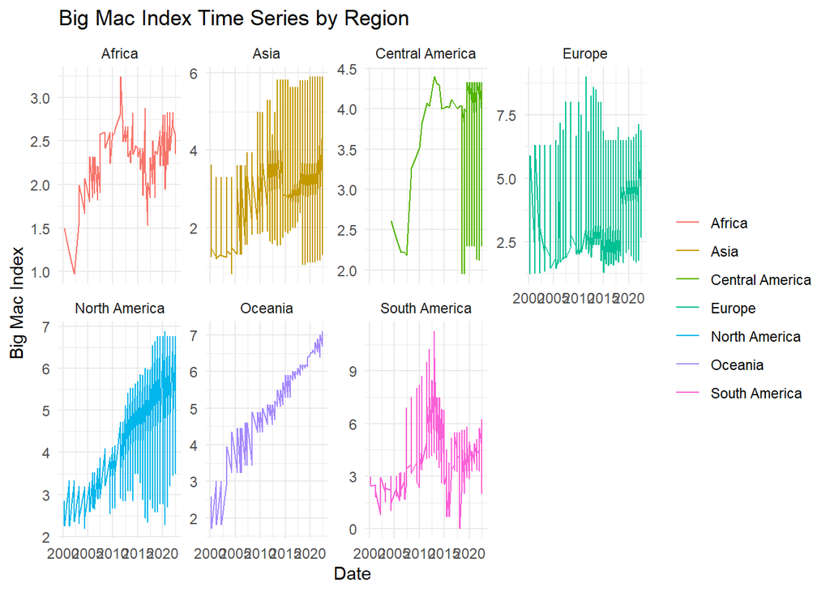

```r
bigmac_region_date <- bigmac_region %>% mutate(Date = as.Date(date, format = "%Y-%m-%d"))


#Regional Big Mac Index trends

ggplot(bigmac_region, aes(x = date, y = dollar_price, color = Region)) +
  geom_line() +
  theme_minimal() +
  labs(title = "Big Mac Index Time Series by Region", x = "Date", y = "Big Mac Index") +
  theme(legend.title = element_blank()) +
  facet_wrap(~ Region, scales = "free_y", nrow = 2)
```

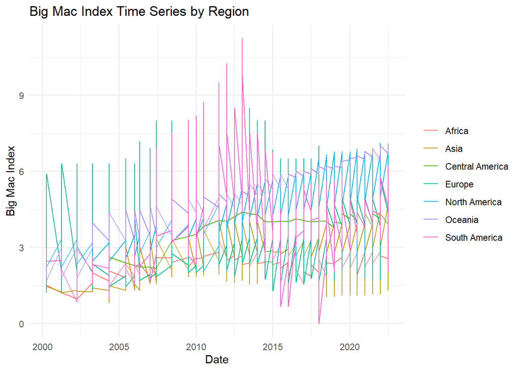

```r
ggplot(bigmac_region, aes(x = date, y = dollar_price, color = Region)) +
  geom_line() +
  theme_minimal() +
  labs(title = "Big Mac Index Time Series by Region", x = "Date", y = "Big Mac Index") +
  theme(legend.title = element_blank())
```

[figure not shown]

```r
bigmac_region_avg <- bigmac_region %>%
  group_by(Region, year = format(date, "%Y")) %>%
  summarize(avg_dollar_price = mean(dollar_price), .groups = "drop")

ggplot(bigmac_region, aes(x = date, y = dollar_price, color = Region)) +
  geom_point(alpha = 0.5) +
  geom_line(data = bigmac_region_avg, aes(x = as.Date(paste(year, "-01-01", sep = ""), format = "%Y-%m-%d"), y = avg_dollar_price), size = 1.5) +
  theme_minimal() +
  labs(title = "Big Mac Index Time Series by Region", x = "Date", y = "Big Mac Index") +
  theme(legend.title = element_blank())
```

From this graph, we see different prices behavior depending of the regions. First, we clearly identify that South America has a lot of prices fluctuation compared to other regions; especially a big decrease between 2013-2015. The other regions are more calm in terms of fluctuation. We especially observe a long and regular increase of prices in Oceania and North America.

```r
#import data inflation to do the correlation between the two datasets
library(readxl)
library(tidyverse)
library(janitor)
inflation_data <- read_excel("imf-dm-export-20230419.xls")
```

```r
inflation_data_clean <- inflation_data %>%
  # Remove first row (full of NA)
  slice(-1) %>%
  # Rename first column to "Country"
  rename(Country = `Inflation rate, average consumer prices (Annual percent change)`) %>%
  # Remove "no data" values and convert to NA
  mutate_all(funs(na_if(., "no data"))) %>%
  # Convert all values to numeric, except "Country"
  mutate_at(vars(-Country), as.numeric) %>%
  # Round all numeric values to 2 decimal, except "Country"
  mutate_at(vars(-Country), round, 2) %>%
  # Wide format to long format
  gather(key = "Year", value = "Inflation_Rate", -Country) %>%
  # Convert "Year" column to integer data type
  mutate(Year = as.integer(Year))
```

```r
#. Remove NA
inf <- na.omit(inflation_data_clean)

# Only keep years from 2000 to 2022
inf_filtered <- inf %>% filter(Year >= 2000 & Year <= 2022)

# to only have the years
bigmac$Year <- format(as.Date(bigmac$date), "%Y")

#Remove unnecessary collumns
bigmacc <- bigmac[, c(-1, -2, -4, -5)]

#Rename column
bigmacc <- bigmacc %>%
    rename(Country = country)

#column year in integer
bigmacc$Year <- as.integer(bigmacc$Year)

#
bigmacc <- bigmacc %>%
 group_by(Country, Year) %>%
     summarise(avg_dollar_price = mean(dollar_price, na.rm = TRUE))


#Merge the data per year and country
merged_data <- inner_join(inf_filtered, bigmacc, by = c("Country", "Year"))

# Compute correlations by country
by_country <- merged_data %>%
    group_by(Country)

corr_by_country <- merged_data %>%
     group_by(Country) %>%
     summarise(cor = cor(Inflation_Rate, avg_dollar_price, use = "pairwise.complete.obs"),
               p_value = cor.test(Inflation_Rate, avg_dollar_price, use = "pairwise.complete.obs")$p.value) %>%
     filter(p_value < 0.05)
```

```r
print(corr_by_country)
```

```
## # A tibble: 16 × 3
##    Country        cor   p_value
##    <chr>        <dbl>     <dbl>
##  1 Azerbaijan   0.931 0.0216
##  2 Colombia    -0.511 0.0252
##  3 Costa Rica  -0.788 0.0000614
##  4 Greece       0.736 0.00636
##  5 Guatemala    0.948 0.0140
##  6 Hungary     -0.420 0.0462
##  7 India       -0.678 0.0153
##  8 Indonesia   -0.691 0.000265
##  9 Ireland      0.646 0.0233
## 10 Israel      -0.544 0.0293
## 11 Kuwait       0.979 0.00370
## 12 Lebanon      0.999 0.0287
## 13 Netherlands  0.622 0.0308
## 14 Peru         0.439 0.0463
## 15 Slovenia     0.905 0.0346
## 16 Spain        0.578 0.0492
```